# AllLife_Customer_Segmentation_Project

## Problem Definition and Questions to be Answered

- AllLife Bank wants to focus on its credit card customer base in the next financial year. They have been advised by their marketing research team, that the penetration in the market can be improved. Based on this input, the Marketing team proposes to run personalized campaigns to target new customers as well as upsell to existing customers. Another insight from the market research was that the customers perceive the support services of the back poorly. Based on this, the Operations team wants to upgrade the service delivery model, to ensure that customer queries are resolved faster.

### Objective

- To identify different segments in the existing customer, based on their spending patterns as well as past interaction with the bank, using clustering algorithms, and provide recommendations to the bank on how to better market to and service these customers.

### Data Dictionary

- Sl_No: Primary key of the records
- Customer Key: Customer identification number
- Average Credit Limit: Average credit limit of each customer for all credit cards
- Total credit cards: Total number of credit cards possessed by the customer
- Total visits bank: Total number of visits that customer made (yearly) personally to the bank
- Total visits online: Total number of visits or online logins made by the customer (yearly)
- Total calls made: Total number of calls made by the customer to the bank or its customer service department (yearly)

```python
# this will help in making the Python code more structured automatically (good coding practice)
%load_ext nb_black

# Libraries to help with reading and manipulating data
import numpy as np
import pandas as pd

# Libraries to help with data visualization
import matplotlib.pyplot as plt
import seaborn as sns

# to scale the data using z-score
from sklearn.preprocessing import StandardScaler

# to compute distances
from scipy.spatial.distance import cdist

# to perform k-means clustering and compute silhouette scores
from sklearn.cluster import KMeans
from sklearn.metrics import silhouette_score

# to visualize the elbow curve and silhouette scores
from yellowbrick.cluster import KElbowVisualizer, SilhouetteVisualizer

# to compute distances
from scipy.spatial.distance import pdist

# to perform hierarchical clustering, compute cophenetic correlation, and create dendrograms
from sklearn.cluster import AgglomerativeClustering
from scipy.cluster.hierarchy import dendrogram, linkage, cophenet

# to perform PCA
from sklearn.decomposition import PCA
```

```python
# loading the dataset
data = pd.read_excel("Credit Card Customer Data.xlsx")
```

## **STRUCTURE OF THE DATA**

```python
data.shape
```

```
(660, 7)
```

- There are 660 rows and 7 columns in the dataset.

```python
# viewing a random sample of the dataset
data.sample(n=10, random_state=1)
```

|  | Sl_No | Customer Key | Avg_Credit_Limit | Total_Credit_Cards | Total_visits_bank | Total_visits_online | Total_calls_made |
| --- | --- | --- | --- | --- | --- | --- | --- |
| 547 | 548 | 38125 | 26000 | 4 | 5 | 2 | 4 |
| 353 | 354 | 94437 | 9000 | 5 | 4 | 1 | 3 |
| 499 | 500 | 65825 | 68000 | 6 | 4 | 2 | 2 |
| 173 | 174 | 38410 | 9000 | 2 | 1 | 5 | 8 |
| 241 | 242 | 81878 | 10000 | 4 | 5 | 1 | 3 |
| 341 | 342 | 70779 | 18000 | 4 | 3 | 2 | 0 |
| 647 | 648 | 79953 | 183000 | 9 | 0 | 9 | 2 |
| 218 | 219 | 28208 | 19000 | 3 | 1 | 5 | 7 |
| 120 | 121 | 16577 | 10000 | 4 | 2 | 4 | 6 |
| 134 | 135 | 31256 | 13000 | 4 | 1 | 5 | 7 |

- Random sample of 10 data observations.
- Observation 647 has the most credit cards, the largest credit limit and the most visits online.
- Observation 547 has the most visits to the bank.

```python
# copying the data to another variable to avoid any changes to original data
df = data.copy()
```

```python
df.head()
```

|  | Sl_No | Customer Key | Avg_Credit_Limit | Total_Credit_Cards | Total_visits_bank | Total_visits_online | Total_calls_made |
| --- | --- | --- | --- | --- | --- | --- | --- |
| 0 | 1 | 87073 | 100000 | 2 | 1 | 1 | 0 |
| 1 | 2 | 38414 | 50000 | 3 | 0 | 10 | 9 |
| 2 | 3 | 17341 | 50000 | 7 | 1 | 3 | 4 |
| 3 | 4 | 40496 | 30000 | 5 | 1 | 1 | 4 |
| 4 | 5 | 47437 | 100000 | 6 | 0 | 12 | 3 |

## **DATA PRE-PROCESSING**

```python
# dropping the Sl_No column as it does not provide any useful information
df.drop("Sl_No", axis=1, inplace=True)
```

- dropping Sl_No column as pandas indexing is appropriate.

```python
# dropping the Customer column as it does not provide any useful information
df.drop("Customer Key", axis=1, inplace=True)
```

- dropping Customer Key column as pandas indexing is appropriate.

```python
df.info()
```

```
<class 'pandas.core.frame.DataFrame'>
RangeIndex: 660 entries, 0 to 659
Data columns (total 5 columns):
 #   Column               Non-Null Count  Dtype
---  ------               --------------  -----
 0   Avg_Credit_Limit     660 non-null    int64
 1   Total_Credit_Cards   660 non-null    int64
 2   Total_visits_bank    660 non-null    int64
 3   Total_visits_online  660 non-null    int64
 4   Total_calls_made     660 non-null    int64
dtypes: int64(5)
memory usage: 25.9 KB
```

- We now have 5 columns in the dataset.
- All columns are the int64 data type.
- We have no 'non-null' values in the dataset.

### **Duplicate Data**

```python
# let's check for duplicate observations
df.duplicated().sum()
```

```
11
```

- There are 11 duplicated values in the data set.

```python
df = df[(~df.duplicated())].copy()
```

- dropping the duplicate values

```python
df.describe()
```

|  | Avg_Credit_Limit | Total_Credit_Cards | Total_visits_bank | Total_visits_online | Total_calls_made |
| --- | --- | --- | --- | --- | --- |
| count | 649.000000 | 649.000000 | 649.000000 | 649.000000 | 649.000000 |
| mean | 34878.274268 | 4.708783 | 2.397535 | 2.624037 | 3.590139 |
| std | 37813.736638 | 2.173763 | 1.625148 | 2.952888 | 2.877911 |
| min | 3000.000000 | 1.000000 | 0.000000 | 0.000000 | 0.000000 |
| 25% | 11000.000000 | 3.000000 | 1.000000 | 1.000000 | 1.000000 |
| 50% | 18000.000000 | 5.000000 | 2.000000 | 2.000000 | 3.000000 |
| 75% | 49000.000000 | 6.000000 | 4.000000 | 4.000000 | 5.000000 |
| max | 200000.000000 | 10.000000 | 5.000000 | 15.000000 | 10.000000 |

- Avg_Credit_Limit, Total_visits_online and Total_calls_made are right skewed. The mean is greater than the median.
- Total_Credit_Cards and Total_visits_bank may be evenly distributed.
- Avg_Credit_Limit may have some outliers that need treatment.

```python
# Let's see unique values
cols = df.columns

for col in cols:
    print("Unique values in the column '{}' are \n\n".format(col), df[col].unique())
    print("-" * 100)
```

```
Unique values in the column 'Avg_Credit_Limit' are

 [100000  50000  30000  20000  15000   5000   3000  10000  13000  11000
   9000   6000   8000  19000  16000  18000  17000  14000  12000   7000
  73000  49000  67000  61000  75000  48000  56000  72000  70000  51000
  69000  40000  44000  31000  37000  65000  46000  74000  58000  39000
  52000  33000  47000  71000  41000  59000  64000  45000  54000  66000
  27000  43000  36000  25000  57000  26000  38000  35000  34000  28000
  63000  29000  68000  42000  62000  32000  60000  55000 157000  94000
 163000 131000  96000 136000 121000 158000 108000 166000 176000 178000
  91000 156000 146000  84000 155000 200000 195000 187000 106000 114000
 126000 173000 153000 184000 123000 144000  97000  98000 127000 171000
 186000 183000 111000 112000 132000  95000 172000  99000 145000 167000]
----------------------------------------------------------------------------------------------------
Unique values in the column 'Total_Credit_Cards' are

 [ 2  3  7  5  6  4  1  9  8 10]
----------------------------------------------------------------------------------------------------
Unique values in the column 'Total_visits_bank' are

 [1 0 2 5 3 4]
----------------------------------------------------------------------------------------------------
Unique values in the column 'Total_visits_online' are

 [ 1 10  3 12 11  2  5  4  0 14  7 13 15  6  8  9]
----------------------------------------------------------------------------------------------------
Unique values in the column 'Total_calls_made' are

 [ 0  9  4  3  8  2  1  7  5  6 10]
----------------------------------------------------------------------------------------------------
```

- Avg_Credit_Limit has many unique values.
- Total_Credit_Cards has 10 unique values.
- Total_visits_bank has 6 unique values
- Total_visits_online has 16 unique values.
- Total_calls_made has 11 unique values.

### **Missing Values**

```python
# checking for missing values
df.isna().sum()
```

```
Avg_Credit_Limit       0
Total_Credit_Cards     0
Total_visits_bank      0
Total_visits_online    0
Total_calls_made       0
dtype: int64
```

- There are no missing values in the data.

### **Outlier Treatment**

```python
# determine outliers = 4 * iqr median of Avg_Credit_Limit

quartiles = np.quantile(df["Avg_Credit_Limit"][df["Avg_Credit_Limit"].notnull()], [0.25, 0.75])
Avg_Credit_Limit_4iqr = 4 * (quartiles[1] - quartiles[0])
print(f"Q1 = {quartiles[0]}, Q3 = {quartiles[1]}, 4*IQR = {Avg_Credit_Limit_4iqr}")

outlier_Avg_Credit_Limit = df.loc[np.abs(df['Avg_Credit_Limit'] - df['Avg_Credit_Limit'].median()) > Avg_Credit_Limit_4iqr, 'Avg_Credit_Limit']
outlier_Avg_Credit_Limit
```

```
Q1 = 11000.0, Q3 = 49000.0, 4*IQR = 152000.0
```

```
622    176000
624    178000
630    200000
631    195000
632    187000
637    173000
639    184000
645    171000
646    186000
647    183000
650    195000
654    172000
658    172000
Name: Avg_Credit_Limit, dtype: int64
```

```python
# drop outliers determined in Avg_Credit_Limit

df.drop(outlier_Avg_Credit_Limit.index, axis=0, inplace=True)
```

- Using the 4*IQR method we determine outliers for the Avg_Credit_Limit column and drop the outliers skewing the data.
- We will leave the outliers in Total_visits_online as they are important to the dataset.

```python
df.shape
```

```
(636, 5)
```

- New shape of data after outlier treatment.

## **EDA**

### **Univariate Analysis**

```python
# function to plot a boxplot and a histogram along the same scale.


def histogram_boxplot(data, feature, figsize=(12, 7), kde=False, bins=None):
    """
    Boxplot and histogram combined

    data: dataframe
    feature: dataframe column
    figsize: size of figure (default (12,7))
    kde: whether to the show density curve (default False)
    bins: number of bins for histogram (default None)
    """
    f2, (ax_box2, ax_hist2) = plt.subplots(
        nrows=2,  # Number of rows of the subplot grid= 2
        sharex=True,  # x-axis will be shared among all subplots
        gridspec_kw={"height_ratios": (0.25, 0.75)},
        figsize=figsize,
    )  # creating the 2 subplots
    sns.boxplot(
        data=data, x=feature, ax=ax_box2, showmeans=True, color="violet"
    )  # boxplot will be created and a star will indicate the mean value of the column
    sns.histplot(
        data=data, x=feature, kde=kde, ax=ax_hist2, bins=bins, palette="winter"
    ) if bins else sns.histplot(
        data=data, x=feature, kde=kde, ax=ax_hist2
    )  # For histogram
    ax_hist2.axvline(
        data[feature].mean(), color="green", linestyle="--"
    )  # Add mean to the histogram
    ax_hist2.axvline(
        data[feature].median(), color="black", linestyle="-"
    )  # Add median to the histogram
```

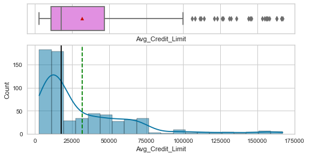

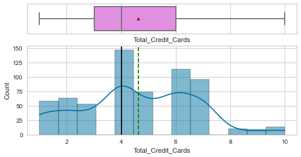

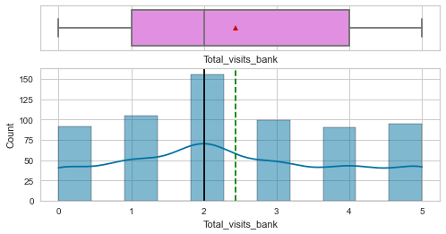

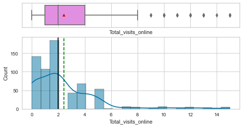

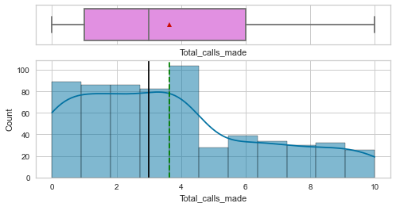

```python
# selecting numerical columns
num_col = df.select_dtypes(include=np.number).columns.tolist()

for item in num_col:
    histogram_boxplot(df, item, kde=True, figsize=(8, 4))
```

- Avg_Credit_Limit, Total_visits_online and Total_calls_made are right skewed. The mean is greater than the median.
- Total_Credit_Cards and Total_visits_bank are somewhat evenly distributed.
- Avg_Credit_Limit and Total_visits_online may have some outliers that need treatment.

```python
# function to create labeled barplots


def labeled_barplot(data, feature, perc=False, n=None):
    """
    Barplot with percentage at the top

    data: dataframe
    feature: dataframe column
    perc: whether to display percentages instead of count (default is False)
    n: displays the top n category levels (default is None, i.e., display all levels)
    """

    total = len(data[feature])  # length of the column
    count = data[feature].nunique()
    if n is None:
        plt.figure(figsize=(count + 1, 5))
    else:
        plt.figure(figsize=(n + 1, 5))

    plt.xticks(rotation=90, fontsize=15)
    ax = sns.countplot(
        data=data,
        x=feature,
        palette="Paired",
        order=data[feature].value_counts().index[:n].sort_values(),
    )

    for p in ax.patches:
        if perc == True:
            label = "{:.1f}%".format(
                100 * p.get_height() / total
            )  # percentage of each class of the category
        else:
            label = p.get_height()  # count of each level of the category

        x = p.get_x() + p.get_width() / 2  # width of the plot
        y = p.get_height()  # height of the plot

        ax.annotate(
            label,
            (x, y),
            ha="center",
            va="center",
            size=12,
            xytext=(0, 5),
            textcoords="offset points",
        )  # annotate the percentage

    plt.show()  # show the plot
```

[figure not shown]

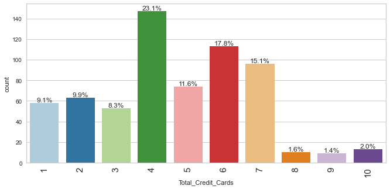

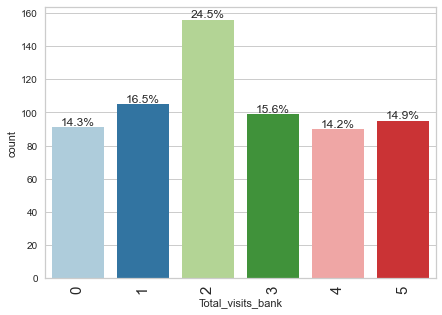

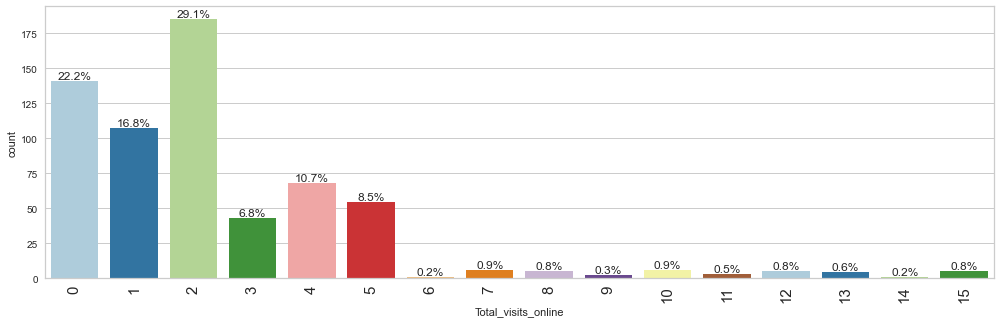

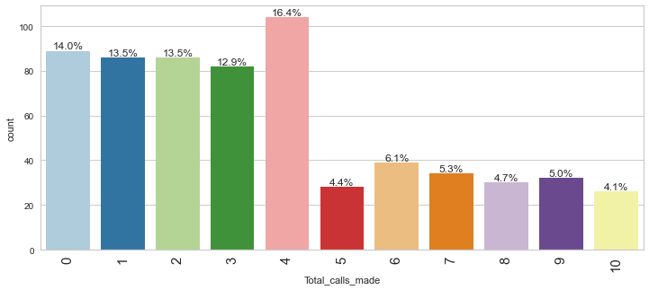

```python
for item in num_col:
    labeled_barplot(df, item, perc=True)
```

- The majority of customer own 4, 5, 6, 7 credit cards.
- 23.1% of customers own 4 cdredit cards.
- 2 visits to the bank is most popular for our customers at 24.5%.
- 14.3% of customer never visit the bank.
- 2 visits online is also the most popular with customers.
- 22.2% do not visit the bank online.
- 4 Total calls made to customer service is the most prominent at 16.4%.
- 14% of customers do not call customer service.

### **Bivariate Analysis**

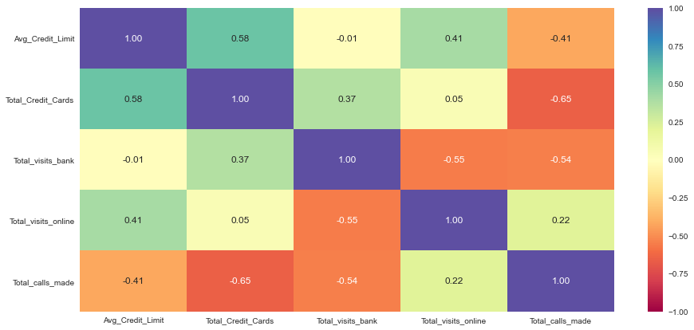

```python
# Heatmap of numerical values
plt.figure(figsize=(15, 7))
sns.heatmap(df[num_col].corr(), annot=True, vmin=-1, vmax=1, fmt=".2f", cmap="Spectral")
plt.show()
```

- Total_Credit_Cards and Avg_Credit_Limit has the high positive correlation at .58. This means as one value increases so will the other.
- Total_visits_online also has a positive correlation with Avg_Credit_Limit and Total_calls_made.
- Total_Credit_Cards and Total_calls_made has the largest negative correlation at -.65. This means as one value increases the other will decrease.
- Total_calls_made also has negative correlations with Total_visits_bank and Avg_Credit_Limit.

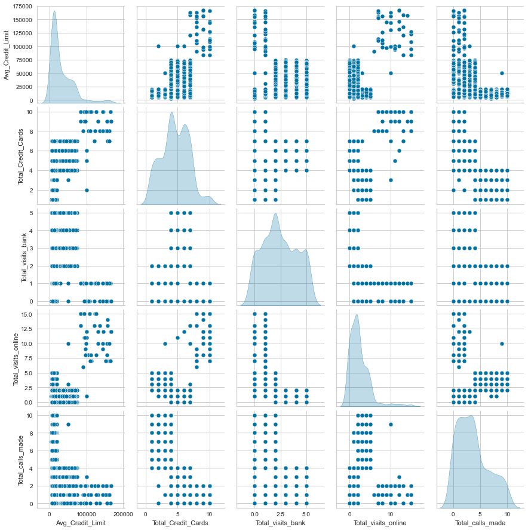

```python
# Pairplot of numerical values
sns.pairplot(data=df[num_col], diag_kind="kde")
plt.show()
```

## **Summary of EDA**

### **Description of Data:**

- There are 660 rows and 7 columns in the dataset.
- There are 11 duplicated values in the data set.
- There are no missing values in the data.
- Avg_Credit_Limit has many unique values.
- Total_Credit_Cards has 10 unique values.
- Total_visits_bank has 6 unique values
- Total_visits_online has 16 unique values.
- Total_calls_made has 11 unique values.

### **Observations:**

- Avg_Credit_Limit, Total_visits_online and Total_calls_made are right skewed. The mean is greater than the median.
- Total_Credit_Cards and Total_visits_bank are somewhat evenly distributed.
- Avg_Credit_Limit and Total_visits_online may have some outliers that need treatment.
- The majority of customer own 4, 5, 6, 7 credit cards.
- 23.1% of customers own 4 cdredit cards.
- 2 visits to the bank is most popular for our customers at 24.5%.
- 14.3% of customer never visit the bank.
- 2 visits online is also the most popular with customers.
- 22.2% do not visit the bank online.
- 4 Total calls made to customer service is the most prominent at 16.4%.
- 14% of customers do not call customer service.
- Total_Credit_Cards and Avg_Credit_Limit has the high positive correlation at .58. This means as one value increases so will the other.
- Total_visits_online also has a positive correlation with Avg_Credit_Limit and Total_calls_made.
- Total_Credit_Cards and Total_calls_made has the largest negative correlation at -.65. This means as one value increases the other will decrease.
- Total_calls_made also has negative correlations with Total_visits_bank and Avg_Credit_Limit.

## **K-means Clustering**

```python
# variables used for clustering
num_col
```

```
['Avg_Credit_Limit',
 'Total_Credit_Cards',
 'Total_visits_bank',
 'Total_visits_online',
 'Total_calls_made']
```

```python
# Scaling the data set before clustering
scaler = StandardScaler()
subset = df[num_col].copy()
subset_scaled = scaler.fit_transform(subset)
```

```python
# Creating a dataframe from the scaled data
subset_scaled_df = pd.DataFrame(subset_scaled, columns=subset.columns)
```

### **Elbow Curve**

```
Number of Clusters: 1 	Average Distortion: 2.025154314172313
Number of Clusters: 2 	Average Distortion: 1.4423039871925372
Number of Clusters: 3 	Average Distortion: 1.1946009116374772
Number of Clusters: 4 	Average Distortion: 1.0973871687633339
Number of Clusters: 5 	Average Distortion: 1.0275673819699673
Number of Clusters: 6 	Average Distortion: 0.9725721190173249
Number of Clusters: 7 	Average Distortion: 0.9353727484916203
Number of Clusters: 8 	Average Distortion: 0.917856372973681
```

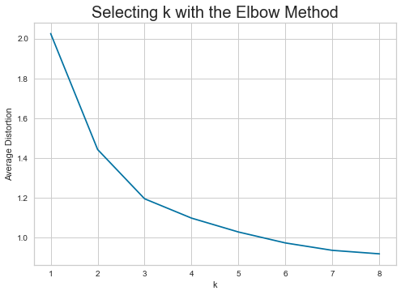

```python
clusters = range(1, 9)
meanDistortions = []

for k in clusters:
    model = KMeans(n_clusters=k)
    model.fit(subset_scaled_df)
    prediction = model.predict(subset_scaled_df)
    distortion = (
        sum(
            np.min(cdist(subset_scaled_df, model.cluster_centers_, "euclidean"), axis=1)
        )
        / subset_scaled_df.shape[0]
    )

    meanDistortions.append(distortion)

    print("Number of Clusters:", k, "\tAverage Distortion:", distortion)

plt.plot(clusters, meanDistortions, "bx-")
plt.xlabel("k")
plt.ylabel("Average Distortion")
plt.title("Selecting k with the Elbow Method", fontsize=20)
```

- The appropriate value of k seems to be 3, 4 or 5.

### **Silhouette Score**

```
For n_clusters = 2, silhouette score is 0.43017177019091185
For n_clusters = 3, silhouette score is 0.5080870893770849
For n_clusters = 4, silhouette score is 0.3431511082592621
For n_clusters = 5, silhouette score is 0.33501269610752965
For n_clusters = 6, silhouette score is 0.2527654514391006
For n_clusters = 7, silhouette score is 0.24842344921021522
For n_clusters = 8, silhouette score is 0.24039677569889412
For n_clusters = 9, silhouette score is 0.22787303884966476
```

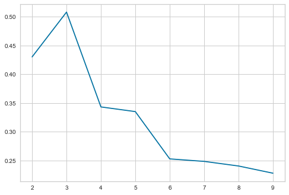

```python
sil_score = []
cluster_list = list(range(2, 10))
for n_clusters in cluster_list:
    clusterer = KMeans(n_clusters=n_clusters)
    preds = clusterer.fit_predict((subset_scaled_df))
    # centers = clusterer.cluster_centers_
    score = silhouette_score(subset_scaled_df, preds)
    sil_score.append(score)
    print("For n_clusters = {}, silhouette score is {}".format(n_clusters, score))

plt.plot(cluster_list, sil_score)
```

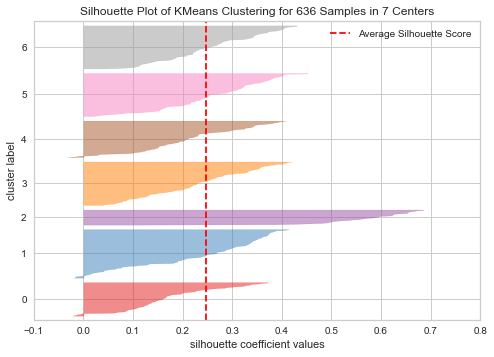

```python
# finding optimal no. of clusters with silhouette coefficients
visualizer = SilhouetteVisualizer(KMeans(7, random_state=1))
visualizer.fit(subset_scaled_df)
visualizer.show()
```

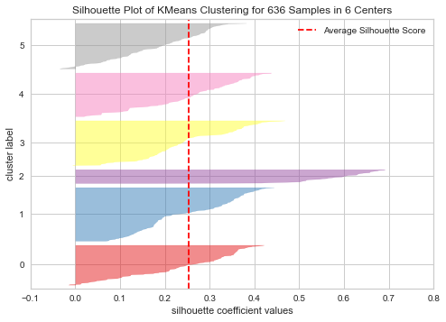

```python
# finding optimal no. of clusters with silhouette coefficients
visualizer = SilhouetteVisualizer(KMeans(6, random_state=1))
visualizer.fit(subset_scaled_df)
visualizer.show()
```

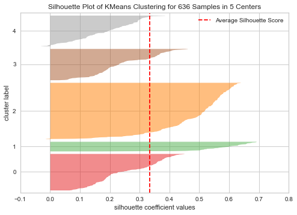

```python
# finding optimal no. of clusters with silhouette coefficients
visualizer = SilhouetteVisualizer(KMeans(5, random_state=1))
visualizer.fit(subset_scaled_df)
visualizer.show()
```

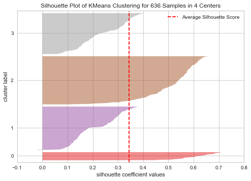

```python
# finding optimal no. of clusters with silhouette coefficients
visualizer = SilhouetteVisualizer(KMeans(4, random_state=1))
visualizer.fit(subset_scaled_df)
visualizer.show()
```

- Let's take 5 as the appropriate no. of clusters as the silhouette score is high enough and there is knick at 5 in the elbow curve.

```python
kmeans = KMeans(n_clusters=5, random_state=0)
kmeans.fit(subset_scaled_df)
```

```
KMeans(n_clusters=5, random_state=0)
```

```python
# adding kmeans cluster labels to the original and scaled dataframes

df["K_means_segments"] = kmeans.labels_
subset_scaled_df["K_means_segments"] = kmeans.labels_
```

### **Cluster Profiling**

```python
cluster_profile = df.groupby("K_means_segments").mean()
```

```python
cluster_profile["count_in_each_segment"] = (
    df.groupby("K_means_segments")["Avg_Credit_Limit"].count().values
)
```

#### **Compare Cluster vs Credit Card Info**

```python
# let's display cluster profiles
cluster_profile.style.highlight_max(color="lightgreen", axis=0)
```

| K_means_segments | Avg_Credit_Limit | Total_Credit_Cards | Total_visits_bank | Total_visits_online | Total_calls_made | count_in_each_segment |
| --- | --- | --- | --- | --- | --- | --- |
| 0 | 60624.000000 | 5.472000 | 3.176000 | 0.880000 | 1.936000 | 125 |
| 1 | 12233.944954 | 2.394495 | 0.940367 | 3.582569 | 6.944954 | 218 |
| 2 | 126486.486486 | 8.729730 | 0.621622 | 10.540541 | 1.189189 | 37 |
| 3 | 22042.553191 | 5.475177 | 4.560284 | 1.063830 | 1.992908 | 141 |
| 4 | 19400.000000 | 5.573913 | 2.443478 | 1.017391 | 2.078261 | 115 |

#### **Observations**

- Cluster 2 has the largest credit limit, number of credit cards, and total visits online.
- Cluster 1 has customers who make the most calls to customer service and the most observations of all clusters.
- Cluster 3 customer frequent the bank most.

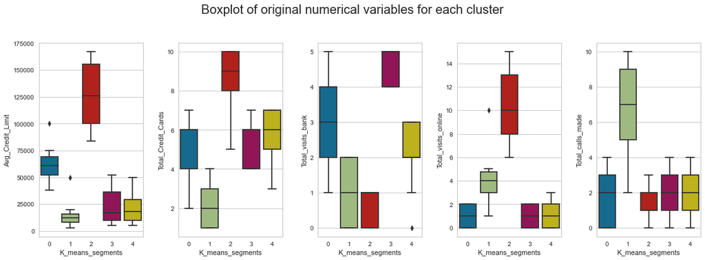

```python
fig, axes = plt.subplots(1, 5, figsize=(16, 6))
fig.suptitle("Boxplot of original numerical variables for each cluster", fontsize=20)
counter = 0
for ii in range(5):
    sns.boxplot(ax=axes[ii], y=df[num_col[counter]], x=df["K_means_segments"])
    counter = counter + 1

fig.tight_layout(pad=2.0)
```

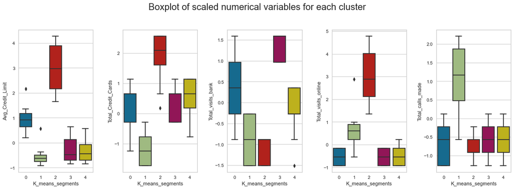

```python
fig, axes = plt.subplots(1, 5, figsize=(16, 6))
fig.suptitle("Boxplot of scaled numerical variables for each cluster", fontsize=20)
counter = 0
for ii in range(5):
    sns.boxplot(
        ax=axes[ii],
        y=subset_scaled_df[num_col[counter]],
        x=subset_scaled_df["K_means_segments"],
    )
    counter = counter + 1

fig.tight_layout(pad=2.0)
```

## **Business Recommendations (K-Means)**

- Cluster 2 has the largest credit limit, number of credit cards, and total visits online. We should focus our marketing campaign on customers who use credit most frequently and cater toward online banking.
- Cluster 1 has customers who make the most calls to customer service and the most observations of all clusters. We should focus our marketing on first time credit card users and expect frequent calls to customer service.
- Cluster 3 customer frequent the bank most. Our marketing campagin should focus on in person banking.

## **Hierarchical Clustering**

```python
# list of distance metrics
distance_metrics = ["euclidean", "chebyshev", "mahalanobis", "cityblock"]

# list of linkage methods
linkage_methods = ["single", "complete", "average", "weighted"]

high_cophenet_corr = 0
high_dm_lm = [0, 0]

for dm in distance_metrics:
    for lm in linkage_methods:
        Z = linkage(subset_scaled_df, metric=dm, method=lm)
        c, coph_dists = cophenet(Z, pdist(subset_scaled_df))
        print(
            "Cophenetic correlation for {} distance and {} linkage is {}.".format(
                dm.capitalize(), lm, c
            )
        )
        if high_cophenet_corr < c:
            high_cophenet_corr = c
            high_dm_lm[0] = dm
            high_dm_lm[1] = lm
```

```
Cophenetic correlation for Euclidean distance and single linkage is 0.8896587209004504.
Cophenetic correlation for Euclidean distance and complete linkage is 0.9063897413921056.
Cophenetic correlation for Euclidean distance and average linkage is 0.9305497245502046.
Cophenetic correlation for Euclidean distance and weighted linkage is 0.9027312600822521.
Cophenetic correlation for Chebyshev distance and single linkage is 0.7974481490123085.
Cophenetic correlation for Chebyshev distance and complete linkage is 0.8248084168359031.
Cophenetic correlation for Chebyshev distance and average linkage is 0.9208766261115812.
Cophenetic correlation for Chebyshev distance and weighted linkage is 0.8821683450389364.
Cophenetic correlation for Mahalanobis distance and single linkage is 0.9118978756728028.
Cophenetic correlation for Mahalanobis distance and complete linkage is 0.4659520513694982.
Cophenetic correlation for Mahalanobis distance and average linkage is 0.8506173044146701.
Cophenetic correlation for Mahalanobis distance and weighted linkage is 0.7777742408916178.
Cophenetic correlation for Cityblock distance and single linkage is 0.917689492401956.
Cophenetic correlation for Cityblock distance and complete linkage is 0.8838894137189914.
Cophenetic correlation for Cityblock distance and average linkage is 0.9125481750987822.
Cophenetic correlation for Cityblock distance and weighted linkage is 0.8815928892663651.
```

```python
# printing the combination of distance metric and linkage method with the highest cophenetic correlation
print(
    "Highest cophenetic correlation is {}, which is obtained with {} distance and {} linkage.".format(
        high_cophenet_corr, high_dm_lm[0].capitalize(), high_dm_lm[1]
    )
)
```

```
Highest cophenetic correlation is 0.9305497245502046, which is obtained with Euclidean distance and average linkage.
```

#### **Let's explore different linkage methods with Euclidean distance only.**

```python
# list of linkage methods
linkage_methods = ["single", "complete", "average", "centroid", "ward", "weighted"]

high_cophenet_corr = 0
high_dm_lm = [0, 0]

for lm in linkage_methods:
    Z = linkage(subset_scaled_df, metric="euclidean", method=lm)
    c, coph_dists = cophenet(Z, pdist(subset_scaled_df))
    print("Cophenetic correlation for {} linkage is {}.".format(lm, c))
    if high_cophenet_corr < c:
        high_cophenet_corr = c
        high_dm_lm[0] = "euclidean"
        high_dm_lm[1] = lm
```

```
Cophenetic correlation for single linkage is 0.8896587209004504.
Cophenetic correlation for complete linkage is 0.9063897413921056.
Cophenetic correlation for average linkage is 0.9305497245502046.
Cophenetic correlation for centroid linkage is 0.9257192806017766.
Cophenetic correlation for ward linkage is 0.8131037528380358.
Cophenetic correlation for weighted linkage is 0.9027312600822521.
```

```python
# printing the combination of distance metric and linkage method with the highest cophenetic correlation
print(
    "Highest cophenetic correlation is {}, which is obtained with {} linkage.".format(
        high_cophenet_corr, high_dm_lm[1]
    )
)
```

```
Highest cophenetic correlation is 0.9305497245502046, which is obtained with average linkage.
```

#### **Observations**

- We see that the cophenetic correlation is maximum with Euclidean distance and average linkage.
- The cophenetic correlation with Chebyshev distance and average linkage is slightly less than the combination with maximum cophenetic correlation.

### **Dendrograms**

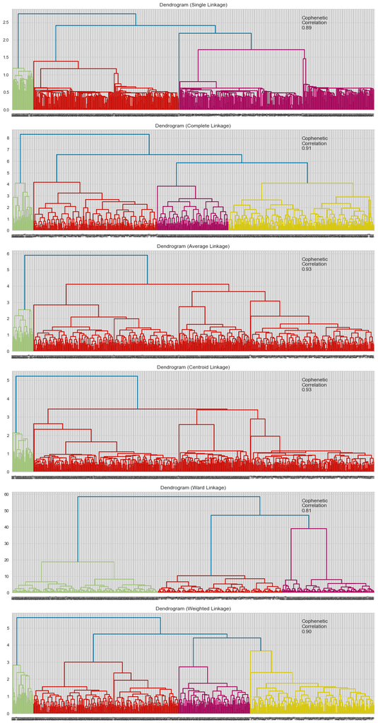

```python
# list of linkage methods
linkage_methods = ["single", "complete", "average", "centroid", "ward", "weighted"]

# lists to save results of cophenetic correlation calculation
compare_cols = ["Linkage", "Cophenetic Coefficient"]

# to create a subplot image
fig, axs = plt.subplots(len(linkage_methods), 1, figsize=(15, 30))

# We will enumerate through the list of linkage methods above
# For each linkage method, we will plot the dendrogram and calculate the cophenetic correlation
for i, method in enumerate(linkage_methods):
    Z = linkage(subset_scaled_df, metric="euclidean", method=method)

    dendrogram(Z, ax=axs[i])
    axs[i].set_title(f"Dendrogram ({method.capitalize()} Linkage)")

    coph_corr, coph_dist = cophenet(Z, pdist(subset_scaled_df))
    axs[i].annotate(
        f"Cophenetic\nCorrelation\n{coph_corr:0.2f}",
        (0.80, 0.80),
        xycoords="axes fraction",
    )
```

#### **Observations**

- Dendrogram for Ward linkage shows distinct and separate clusters.
- The Cophenetic Corrrelation is highest with Centroid and Average linkage.

### **Cluster Profiling**

#### **Average Linkage**

```python
HCmodel = AgglomerativeClustering(n_clusters=5, affinity="euclidean", linkage="average")
HCmodel.fit(subset_scaled_df)
```

```
AgglomerativeClustering(linkage='average', n_clusters=5)
```

```python
subset_scaled_df["HC_Clusters"] = HCmodel.labels_
df["HC_Clusters"] = HCmodel.labels_
```

```python
cluster_profile = df.groupby("HC_Clusters").mean()
```

```python
cluster_profile["count_in_each_segments"] = (
    df.groupby("HC_Clusters")["Avg_Credit_Limit"].count().values
)
```

```python
# let's see the number of credit cards in each cluster
for cl in df["HC_Clusters"].unique():
    print("In cluster {}, the total number of credit cards are present:".format(cl))
    print(df[df["HC_Clusters"] == cl]["Total_Credit_Cards"].unique())
    print()
```

```
In cluster 1, the total number of credit cards are present:
[2 6 5 7 4]

In cluster 4, the total number of credit cards are present:
[3]

In cluster 0, the total number of credit cards are present:
[7 5 3 4 6]

In cluster 3, the total number of credit cards are present:
[ 6  5  9  8 10  7]

In cluster 2, the total number of credit cards are present:
[3 2 4 1]
```

```python
# let's see the number of bank visits in each cluster
for cl in df["HC_Clusters"].unique():
    print("In cluster {}, the total number of bank visits are present:".format(cl))
    print(df[df["HC_Clusters"] == cl]["Total_visits_bank"].unique())
    print()
```

```
In cluster 1, the total number of bank visits are present:
[1 4 3 2 5]

In cluster 4, the total number of bank visits are present:
[0]

In cluster 0, the total number of bank visits are present:
[1 0 2 5 3 4]

In cluster 3, the total number of bank visits are present:
[0 1]

In cluster 2, the total number of bank visits are present:
[0 2 1]
```

- Cluster 0 has customers who visit the bank most often.
- Customers in cluster 4 took no bank visits.

```python
# let's see the number of visits online in each cluster
for cl in df["HC_Clusters"].unique():
    print("In cluster {}, the total number of visits online are present:".format(cl))
    print(df[df["HC_Clusters"] == cl]["Total_visits_online"].unique())
    print()
```

```
In cluster 1, the total number of visits online are present:
[1 2 0]

In cluster 4, the total number of visits online are present:
[10]

In cluster 0, the total number of visits online are present:
[3 1 0 2]

In cluster 3, the total number of visits online are present:
[12 11 14  7 10 13 15  6  8  9]

In cluster 2, the total number of visits online are present:
[1 2 5 4 3]
```

- Cluster 3 has an overwhelming majority of number of online visits.

```python
# let's see the total number of calls made in each cluster
for cl in df["HC_Clusters"].unique():
    print("In cluster {}, the total number of calls made are present:".format(cl))
    print(df[df["HC_Clusters"] == cl]["Total_calls_made"].unique())
    print()
```

```
In cluster 1, the total number of calls made are present:
[0 2 1 4 3]

In cluster 4, the total number of calls made are present:
[9]

In cluster 0, the total number of calls made are present:
[4 1 0 2 3]

In cluster 3, the total number of calls made are present:
[3 2 1 0]

In cluster 2, the total number of calls made are present:
[ 8  2  7  5  9  6  4 10]
```

- Cluster 2 has the most number of calls to customer service.

```python
HCmodel = AgglomerativeClustering(n_clusters=5, affinity="euclidean", linkage="ward")
HCmodel.fit(subset_scaled_df)
```

```
AgglomerativeClustering(n_clusters=5)
```

```python
cluster_profile["count_in_each_segments"] = (
    df.groupby("HC_Clusters")["Avg_Credit_Limit"].count().values
)
```

```python
# let's see the total number of credit cards in each cluster
for cl in df["HC_Clusters"].unique():
    print(
        "The",
        df[df["HC_Clusters"] == cl]["Total_Credit_Cards"].nunique(),
        "credit cards in cluster",
        cl,
        "are:",
    )
    print(df[df["HC_Clusters"] == cl]["Total_Credit_Cards"].unique())
    print("-" * 100, "\n")
```

```
The 5 credit cards in cluster 1 are:
[2 6 5 7 4]
----------------------------------------------------------------------------------------------------

The 1 credit cards in cluster 4 are:
[3]
----------------------------------------------------------------------------------------------------

The 5 credit cards in cluster 0 are:
[7 5 3 4 6]
----------------------------------------------------------------------------------------------------

The 6 credit cards in cluster 3 are:
[ 6  5  9  8 10  7]
----------------------------------------------------------------------------------------------------

The 4 credit cards in cluster 2 are:
[3 2 4 1]
----------------------------------------------------------------------------------------------------
```

```python
# let's see the number of bank visits in each cluster
for cl in df["HC_Clusters"].unique():
    print(
        "The",
        df[df["HC_Clusters"] == cl]["Total_visits_bank"].nunique(),
        "bank visits in cluster",
        cl,
        "are:",
    )
    print(df[df["HC_Clusters"] == cl]["Total_visits_bank"].unique())
    print("-" * 100, "\n")
```

```
The 5 bank visits in cluster 1 are:
[1 4 3 2 5]
----------------------------------------------------------------------------------------------------

The 1 bank visits in cluster 4 are:
[0]
----------------------------------------------------------------------------------------------------

The 6 bank visits in cluster 0 are:
[1 0 2 5 3 4]
----------------------------------------------------------------------------------------------------

The 2 bank visits in cluster 3 are:
[0 1]
----------------------------------------------------------------------------------------------------

The 3 bank visits in cluster 2 are:
[0 2 1]
----------------------------------------------------------------------------------------------------
```

```python
# let's see the number of online visits in each cluster
for cl in df["HC_Clusters"].unique():
    print(
        "The",
        df[df["HC_Clusters"] == cl]["Total_visits_online"].nunique(),
        "online visits in cluster",
        cl,
        "are:",
    )
    print(df[df["HC_Clusters"] == cl]["Total_visits_online"].unique())
    print("-" * 100, "\n")
```

```
The 3 online visits in cluster 1 are:
[1 2 0]
----------------------------------------------------------------------------------------------------

The 1 online visits in cluster 4 are:
[10]
----------------------------------------------------------------------------------------------------

The 4 online visits in cluster 0 are:
[3 1 0 2]
----------------------------------------------------------------------------------------------------

The 10 online visits in cluster 3 are:
[12 11 14  7 10 13 15  6  8  9]
----------------------------------------------------------------------------------------------------

The 5 online visits in cluster 2 are:
[1 2 5 4 3]
----------------------------------------------------------------------------------------------------
```

```python
# let's see the number of calls made in each cluster
for cl in df["HC_Clusters"].unique():
    print(
        "The",
        df[df["HC_Clusters"] == cl]["Total_calls_made"].nunique(),
        "calls made in cluster",
        cl,
        "are:",
    )
    print(df[df["HC_Clusters"] == cl]["Total_calls_made"].unique())
    print("-" * 100, "\n")
```

```
The 5 calls made in cluster 1 are:
[0 2 1 4 3]
----------------------------------------------------------------------------------------------------

The 1 calls made in cluster 4 are:
[9]
----------------------------------------------------------------------------------------------------

The 5 calls made in cluster 0 are:
[4 1 0 2 3]
----------------------------------------------------------------------------------------------------

The 4 calls made in cluster 3 are:
[3 2 1 0]
----------------------------------------------------------------------------------------------------

The 8 calls made in cluster 2 are:
[ 8  2  7  5  9  6  4 10]
----------------------------------------------------------------------------------------------------
```

#### **Compare Cluster vs Credit Card Info**

```python
# lets display cluster profile
cluster_profile.style.highlight_max(color="lightgreen", axis=0)
```

| HC_Clusters | Avg_Credit_Limit | Total_Credit_Cards | Total_visits_bank | Total_visits_online | Total_calls_made | K_means_segments | count_in_each_segments |
| --- | --- | --- | --- | --- | --- | --- | --- |
| 0 | 20855.468750 | 5.519531 | 3.609375 | 1.042969 | 2.031250 | 3.449219 | 256 |
| 1 | 60624.000000 | 5.472000 | 3.176000 | 0.880000 | 1.936000 | 0.000000 | 125 |
| 2 | 12059.907834 | 2.391705 | 0.944700 | 3.552995 | 6.935484 | 1.000000 | 217 |
| 3 | 126486.486486 | 8.729730 | 0.621622 | 10.540541 | 1.189189 | 2.000000 | 37 |
| 4 | 50000.000000 | 3.000000 | 0.000000 | 10.000000 | 9.000000 | 1.000000 | 1 |

- Cluster 3 has the largest Avg_Credit_Limit, Total_Credit_Cards and Total_visits_online. Our marketing should be catered to a customer who makes a lot of purchases and uses online banking.
- Cluster 0 has the most bank visits and the most segment counts.

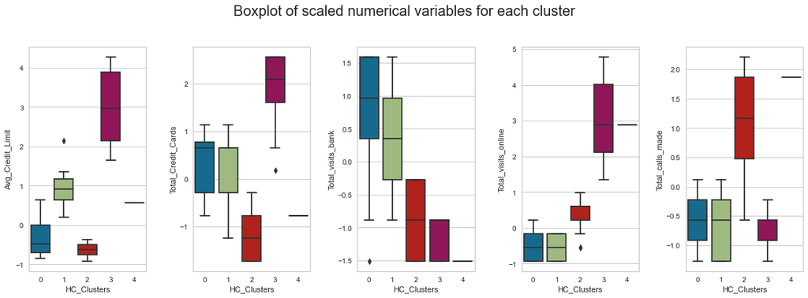

```python
fig, axes = plt.subplots(1, 5, figsize=(16, 6))
fig.suptitle("Boxplot of scaled numerical variables for each cluster", fontsize=20)
counter = 0
for ii in range(5):
    sns.boxplot(
        ax=axes[ii],
        y=subset_scaled_df[num_col[counter]],
        x=subset_scaled_df["HC_Clusters"],
    )
    counter = counter + 1

fig.tight_layout(pad=2.0)
```

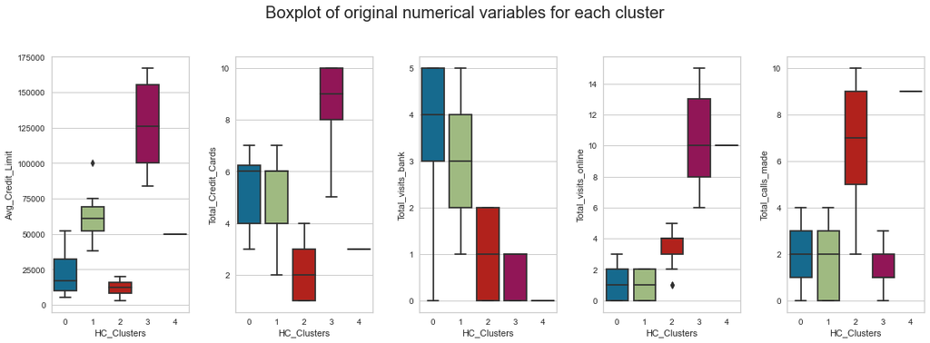

```python
fig, axes = plt.subplots(1, 5, figsize=(16, 6))
fig.suptitle("Boxplot of original numerical variables for each cluster", fontsize=20)
counter = 0
for ii in range(5):
    sns.boxplot(ax=axes[ii], y=df[num_col[counter]], x=df["HC_Clusters"])
    counter = counter + 1

fig.tight_layout(pad=2.0)
```

#### **Created by Stephen Catalfio**